# DS311 - R Lab Assignment

Vinh Tran

2024-11-04

## R Assignment 1

- In this assignment, we are going to apply some of the build in data set in R for descriptive statistics analysis.
- To earn full grade in this assignment, students need to complete the coding tasks for each question to get the result.
- After finished all the questions, knit the document into HTML format for submission.

### Question 1

Using the **mtcars** data set in R, please answer the following questions.

```r
# Loading the data
data(mtcars)

# Head of the data set
head(mtcars)
```

|  | mpg | cyl | disp | hp | drat | wt | qsec | vs | am | gear | carb |
| --- | --- | --- | --- | --- | --- | --- | --- | --- | --- | --- | --- |
| Mazda RX4 | 21.0 | 6 | 160 | 110 | 3.90 | 2.620 | 16.46 | 0 | 1 | 4 | 4 |
| Mazda RX4 Wag | 21.0 | 6 | 160 | 110 | 3.90 | 2.875 | 17.02 | 0 | 1 | 4 | 4 |
| Datsun 710 | 22.8 | 4 | 108 | 93 | 3.85 | 2.320 | 18.61 | 1 | 1 | 4 | 1 |
| Hornet 4 Drive | 21.4 | 6 | 258 | 110 | 3.08 | 3.215 | 19.44 | 1 | 0 | 3 | 1 |
| Hornet Sportabout | 18.7 | 8 | 360 | 175 | 3.15 | 3.440 | 17.02 | 0 | 0 | 3 | 2 |
| Valiant | 18.1 | 6 | 225 | 105 | 2.76 | 3.460 | 20.22 | 1 | 0 | 3 | 1 |

1. Report the number of variables and observations in the data set.

```r
# Enter your code here!
num_variables <- ncol(mtcars)
num_observations <- nrow(mtcars)

# Answer:
print(paste("There are a total of", num_variables, "variables and", num_observations, "observations in this dataset."))
```

```
## [1] "There are a total of 11 variables and 32 observations in this dataset."
```

2. Print the summary statistics of the data set and report how many discrete and continuous variables are in the data set.

```r
# Enter your code here!
discrete_count <- 0
continuous_count <- 0

for (variable in names(mtcars)) {
  column <- mtcars[[variable]]

  if (all(column == floor(column))) {
    discrete_count<- discrete_count +1
  } else {
    continuous_count <- continuous_count+1
  }
}

print(paste("The dataset has", discrete_count, "discrete variables and", continuous_count, "continuous variables."))
```

```
## [1] "The dataset has 6 discrete variables and 5 continuous variables."
```

```r
# Answer:
print(paste("The dataset has", discrete_count, "discrete variables and", continuous_count, "continuous variables."))
```

```
## [1] "The dataset has 6 discrete variables and 5 continuous variables."
```

3. Calculate the mean, variance, and standard deviation for the variable **mpg** and assign them into variable names m, v, and s. Report the results in the print statement.

```r
# Enter your code here!
m <- round(mean(mtcars$mpg), 2)
v <- round(var(mtcars$mpg), 2)
s <- round(sd(mtcars$mpg), 2)



# Answer:
print(paste("The average of Mile Per Gallon from this data set is ", m , " with variance ", v , " and standard deviation", s  , "."))
```

```
## [1] "The average of Mile Per Gallon from this data set is  20.09  with variance  36.32  and standard deviation 6.03 ."
```

4. Create two tables to summarize 1) average mpg for each cylinder class and 2) the standard deviation of mpg for each gear class.

```r
# Enter your code here!
avg_mpg_cyl <- tapply(mtcars$mpg, mtcars$cyl, mean)
sd_mpg_gear <- tapply(mtcars$mpg, mtcars$gear, sd)

print("Average mpg for each cylinder class:")
```

```
## [1] "Average mpg for each cylinder class:"
```

```r
print(avg_mpg_cyl)
```

```
##        4        6        8
## 26.66364 19.74286 15.10000
```

```r
print("Standard deviation of mpg for each gear class:")
```

```
## [1] "Standard deviation of mpg for each gear class:"
```

```r
print(sd_mpg_gear)
```

```
##        3        4        5
## 3.371618 5.276764 6.658979
```

5. Create a crosstab that shows the number of observations belong to each cylinder and gear class combinations. The table should show how many observations given the car has 4 cylinders with 3 gears, 4 cylinders with 4 gears, etc. Report which combination is recorded in this data set and how many observations for this type of car.

```r
# Enter your code here!
cyl_gear_table <- table(mtcars$cyl, mtcars$gear)

print("Crosstab of cylinder and gear class combinations:")
```

```
## [1] "Crosstab of cylinder and gear class combinations:"
```

```r
print(cyl_gear_table)
```

```
##
##      3  4  5
##   4  1  8  2
##   6  2  4  1
##   8 12  0  2
```

```r
max_combination <- which(cyl_gear_table == max(cyl_gear_table), arr.ind = TRUE)
cyl_class <- rownames(cyl_gear_table)[max_combination[1]]
gear_class <- colnames(cyl_gear_table)[max_combination[2]]
max_count <- cyl_gear_table[max_combination]

print(paste("The combination with the highest number of observations is", cyl_class, "cylinders and", gear_class, "gears, with", max_count, "observations."))
```

```
## [1] "The combination with the highest number of observations is 8 cylinders and 3 gears, with 12 observations."
```

### Question 2

Use different visualization tools to summarize the data sets in this question.

1. Using the **PlantGrowth** data set, visualize and compare the weight of the plant in the three separated group. Give labels to the title, x-axis, and y-axis on the graph. Write a paragraph to summarize your findings.

```r
# Load the data set
data("PlantGrowth")

# Head of the data set
PlantGrowth
```

| weight | group |
| --- | --- |
| 4.17 | ctrl |
| 5.58 | ctrl |
| 5.18 | ctrl |
| 6.11 | ctrl |
| 4.50 | ctrl |
| 4.61 | ctrl |
| 5.17 | ctrl |
| 4.53 | ctrl |
| 5.33 | ctrl |
| 5.14 | ctrl |

[output cut: 20 more lines]

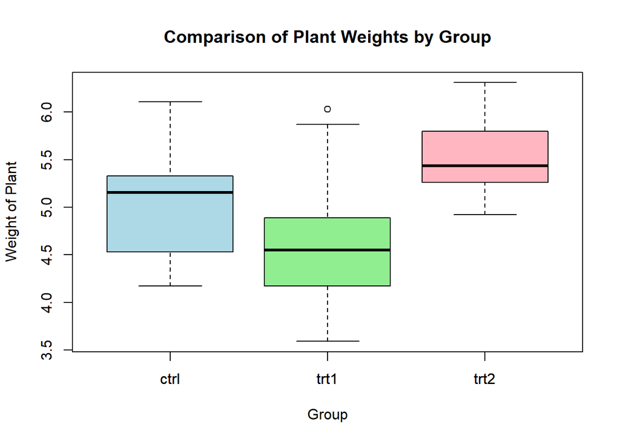

```r
# Enter your code here!
boxplot(weight ~ group, data = PlantGrowth,
        main = "Comparison of Plant Weights by Group",
        xlab = "Group",
        ylab = "Weight of Plant",
        col = c("lightblue", "lightgreen", "lightpink"))

axis(1, at = 1:3, labels = c("ctrl", "trt1", "trt2"))
```

Result:

2. Using the **mtcars** data set, plot the histogram for the column **mpg** with 10 breaks. Give labels to the title, x-axis, and y-axis on the graph. Report the most observed mpg class from the data set.

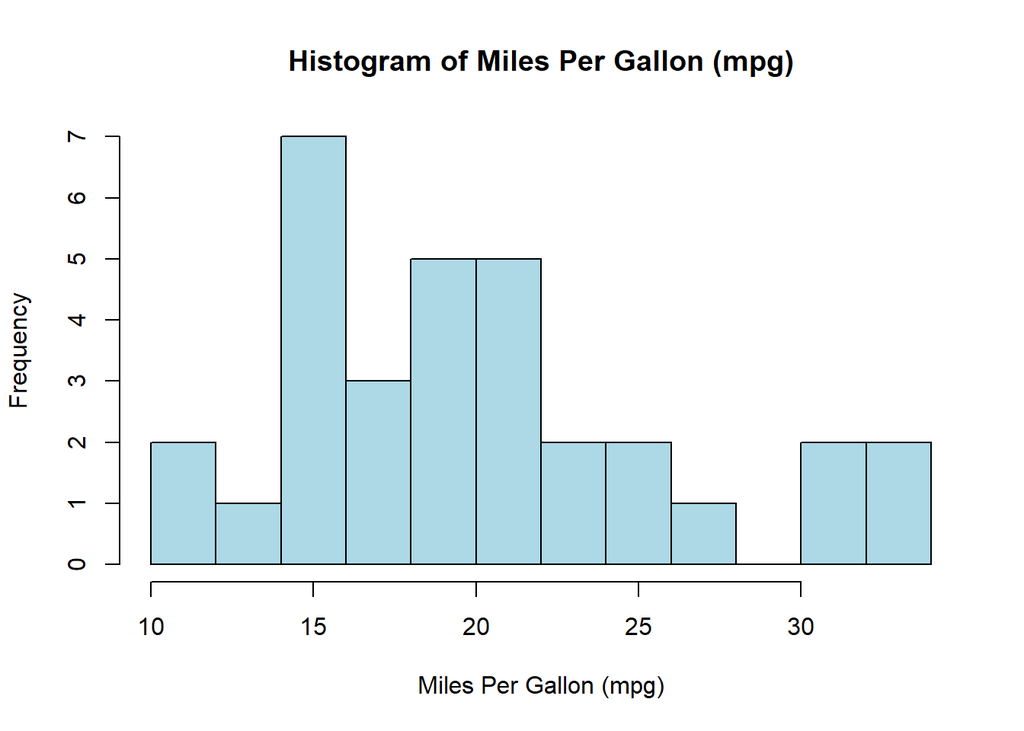

```r
hist(mtcars$mpg, breaks = 10,
     main = "Histogram of Miles Per Gallon (mpg)",
     xlab = "Miles Per Gallon (mpg)",
     ylab = "Frequency",
     col = "lightblue")
```

```r
hist_data <- hist(mtcars$mpg, breaks = 10, plot = FALSE)
most_observed_class <- which.max(hist_data$counts)
most_observed_range <- paste(hist_data$breaks[most_observed_class],
                             "-",
                             hist_data$breaks[most_observed_class + 1])

print(paste("The most observed mpg class is:", most_observed_range, "miles per gallon."))
```

```
## [1] "The most observed mpg class is: 14 - 16 miles per gallon."
```

3. Using the **USArrests** data set, create a pairs plot to display the correlations between the variables in the data set. Plot the scatter plot with **Murder** and **Assault**. Give labels to the title, x-axis, and y-axis on the graph. Write a paragraph to summarize your results from both plots.

```r
# Load the data set
data("USArrests")

# Head of the data set
head(USArrests)
```

|  | Murder | Assault | UrbanPop | Rape |
| --- | --- | --- | --- | --- |
| Alabama | 13.2 | 236 | 58 | 21.2 |
| Alaska | 10.0 | 263 | 48 | 44.5 |
| Arizona | 8.1 | 294 | 80 | 31.0 |
| Arkansas | 8.8 | 190 | 50 | 19.5 |
| California | 9.0 | 276 | 91 | 40.6 |
| Colorado | 7.9 | 204 | 78 | 38.7 |

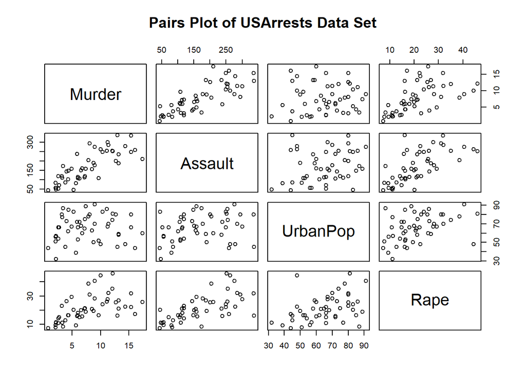

```r
# Enter your code here!

pairs(USArrests, main = "Pairs Plot of USArrests Data Set")
```

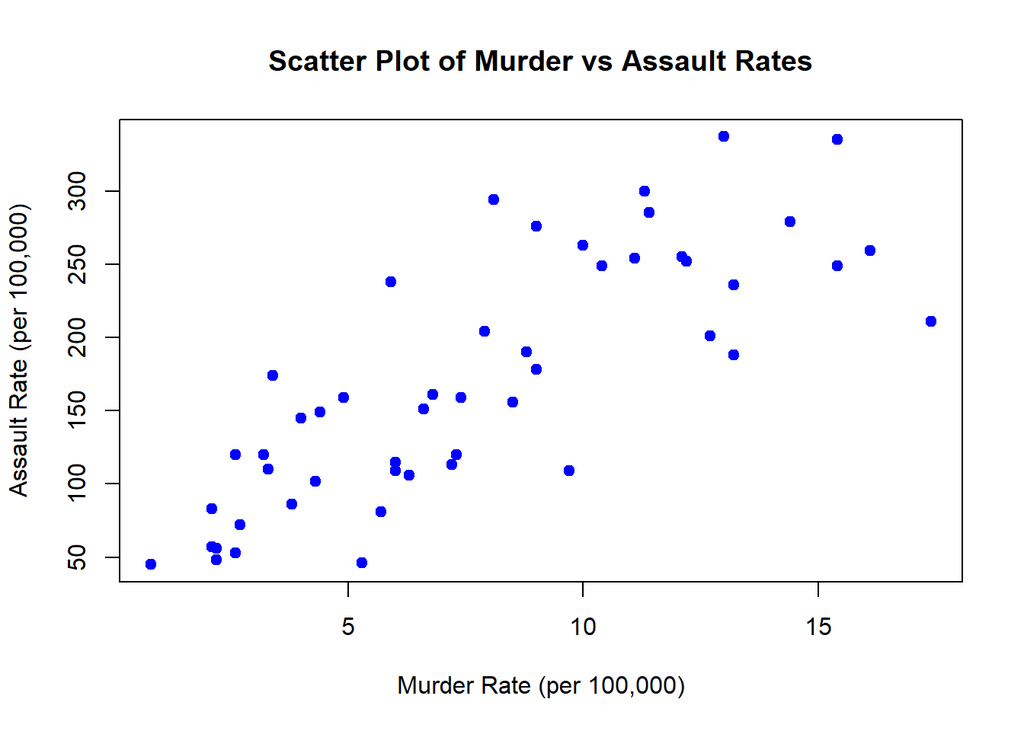

```r
plot(USArrests$Murder, USArrests$Assault,
     main = "Scatter Plot of Murder vs Assault Rates",
     xlab = "Murder Rate (per 100,000)",
     ylab = "Assault Rate (per 100,000)",
     col = "blue",
     pch = 19)
```

Result:

=> Report a paragraph to summarize your findings from the plot!

The pairs plot of the ‘USArrests’ data set shows all possible scatter plots between the variables ‘Murder’, ‘Assault’, ‘UrbanPop’, and ‘Rape.’ The pairs plot provides an overview of potential correlations between the variables. From visual inspection, there seems to be a positive correlation between ‘Murder’ and ‘Assault’ rates, as well as between ‘Assault’ and ‘Rape’ rates. The ‘UrbanPop’ variable, which represents the percentage of the population living in urban areas, appears to be less strongly correlated with the other variables.The scatter plot between ‘Murder’ and ‘Assault’ rates indicates a strong positive relationship, meaning that states with higher murder rates tend to also have higher assault rates. This suggests that violent crime rates for these two types of offenses tend to increase together. The positive linear trend is clear in the scatter plot, and most data points cluster along an upward trend line, suggesting a strong linear association between these two variables.

### Question 3

Download the housing data set from www.jaredlander.com and find out what explains the housing prices in New York City.

Note: Check your working directory to make sure that you can download the data into the data folder.

|  | Neighborhood | Market.Value.per.SqFt | Boro | Year.Built |
| --- | --- | --- | --- | --- |
| 1 | FINANCIAL | 200.00 | Manhattan | 1920 |
| 2 | FINANCIAL | 242.76 | Manhattan | 1985 |
| 4 | FINANCIAL | 271.23 | Manhattan | 1930 |
| 5 | TRIBECA | 247.48 | Manhattan | 1985 |
| 6 | TRIBECA | 191.37 | Manhattan | 1986 |
| 7 | TRIBECA | 211.53 | Manhattan | 1985 |
| 8 | TRIBECA | 222.33 | Manhattan | 1986 |
| 9 | TRIBECA | 259.21 | Manhattan | 1987 |
| 10 | TRIBECA | 205.62 | Manhattan | 1985 |
| 11 | TRIBECA | 222.34 | Manhattan | 1986 |

[output cut: 2520 more lines]

1. Create your own descriptive statistics and aggregation tables to summarize the data set and find any meaningful results between different variables in the data set.

```r
# Head of the cleaned data set
head(housingData)
```

|  | Neighborhood | Market.Value.per.SqFt | Boro | Year.Built |
| --- | --- | --- | --- | --- |
| 1 | FINANCIAL | 200.00 | Manhattan | 1920 |
| 2 | FINANCIAL | 242.76 | Manhattan | 1985 |
| 4 | FINANCIAL | 271.23 | Manhattan | 1930 |
| 5 | TRIBECA | 247.48 | Manhattan | 1985 |
| 6 | TRIBECA | 191.37 | Manhattan | 1986 |
| 7 | TRIBECA | 211.53 | Manhattan | 1985 |

```r
# Enter your code here!

# Descriptive Statistics
mean_value <- mean(housingData$Market.Value.per.SqFt)
median_value <- median(housingData$Market.Value.per.SqFt)
sd_value <- sd(housingData$Market.Value.per.SqFt)
quantiles <- quantile(housingData$Market.Value.per.SqFt)

print(paste("Mean Market Value per SqFt: $", round(mean_value, 2)))
```

```
## [1] "Mean Market Value per SqFt: $ 133.17"
```

```r
print(paste("Median Market Value per SqFt: $", round(median_value, 2)))
```

```
## [1] "Median Market Value per SqFt: $ 114.89"
```

```r
print(paste("Standard Deviation of Market Value per SqFt: $", round(sd_value, 2)))
```

```
## [1] "Standard Deviation of Market Value per SqFt: $ 68.88"
```

```r
print("Quantiles of Market Value per SqFt:")
```

```
## [1] "Quantiles of Market Value per SqFt:"
```

```r
print(quantiles)
```

```
##      0%     25%     50%     75%    100%
##  10.660  75.100 114.890 189.915 399.380
```

```r
# Relationship b/w Year Built and Avg Market Value per Sq Ft
housingData$Decade <- floor(housingData$Year.Built / 10) * 10

avg_market_value_decade <- aggregate(Market.Value.per.SqFt ~ Decade, data = housingData, mean)

print("Average Market Value per SqFt by Decade:")
```

```
## [1] "Average Market Value per SqFt by Decade:"
```

```r
print(avg_market_value_decade)
```

```
##    Decade Market.Value.per.SqFt
## 1    1820              76.36000
## 2    1830             273.77000
## 3    1850             152.79000
## 4    1860             159.64500
## 5    1870             166.46200
## 6    1880             130.50333
## 7    1890             114.04053
## 8    1900             146.82888
## 9    1910             151.46995
## 10   1920             138.96598
## 11   1930             116.90672
## 12   1940             126.48531
## 13   1950             134.86619
## 14   1960             117.18471
## 15   1970             180.52840
## 16   1980             144.46210
## 17   1990             119.61954
## 18   2000             125.34869
## 19   2010              90.36667
```

2. Create multiple plots to demonstrates the correlations between different variables. Remember to label all axes and give title to each graph.

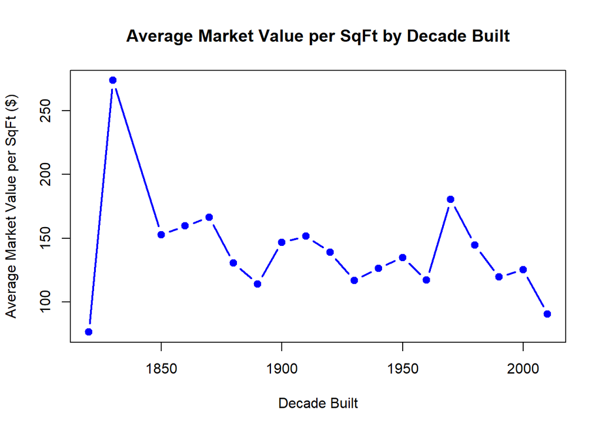

```r
# Enter your code here!

# Graph of Decade Built vs Avg Market Value per Sq Ft
plot(avg_market_value_decade,
     type = "b",
     main = "Average Market Value per SqFt by Decade Built",
     xlab = "Decade Built",
     ylab = "Average Market Value per SqFt ($)",
     col = "blue",
     pch = 19,
     lwd = 2)
```

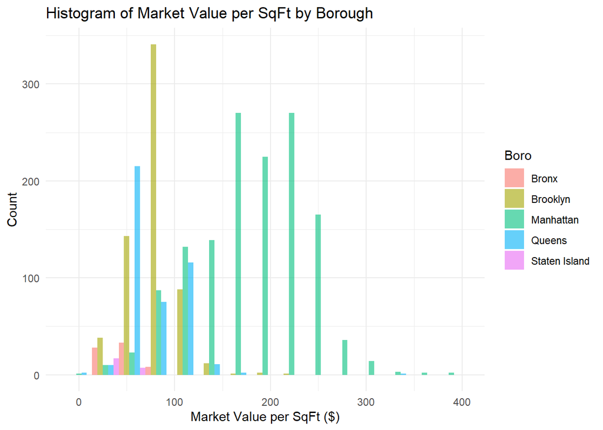

```r
# Histogram of Market Value per Square Foot by Borough
library(ggplot2)
ggplot(housingData, aes(x = Market.Value.per.SqFt, fill = Boro)) +
  geom_histogram(bins = 15, alpha = 0.6, position = "dodge") +
  labs(title = "Histogram of Market Value per SqFt by Borough",
       x = "Market Value per SqFt ($)",
       y = "Count") +
  theme_minimal()
```

3. Write a summary about your findings from this exercise.